# 03_translate_flip_sqrt

## 03_translate_flip_sqrt

#### Question

1. Consider the $y=\sqrt{x}$ curve shown below. In the context of transforming functions, a very simple function is often called a “parent” function.

   The following 8 graphs are made by translating and reflecting the $y=\sqrt{x}$ curve. So each one is a different daughter function, made by altering the parent function.

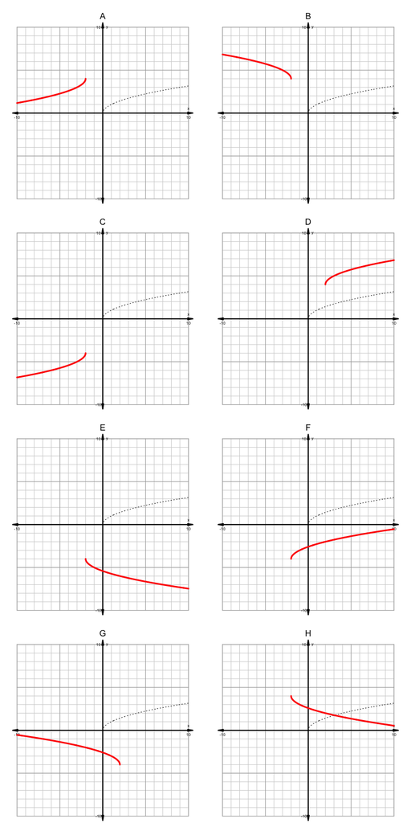

   Match the 8 graphs with the equations.
   1. Equation $y=\sqrt{-(x+2)}+4$ matches graph .
   2. Equation $y=-\sqrt{x+2}+4$ matches graph .
   3. Equation $y=\sqrt{x+2}-4$ matches graph .
   4. Equation $y=\sqrt{x-2}+4$ matches graph .
   5. Equation $y=-\sqrt{x+2}-4$ matches graph .
   6. Equation $y=\sqrt{-(x-2)}-4$ matches graph .
   7. Equation $y=-\sqrt{-(x+2)}-4$ matches graph .
   8. Equation $y=-\sqrt{-(x+2)}+4$ matches graph .

#### Question

2. Consider the $y=\sqrt{x}$ curve shown below. In the context of transforming functions, a very simple function is often called a “parent” function.

   The following 8 graphs are made by translating and reflecting the $y=\sqrt{x}$ curve. So each one is a different daughter function, made by altering the parent function.

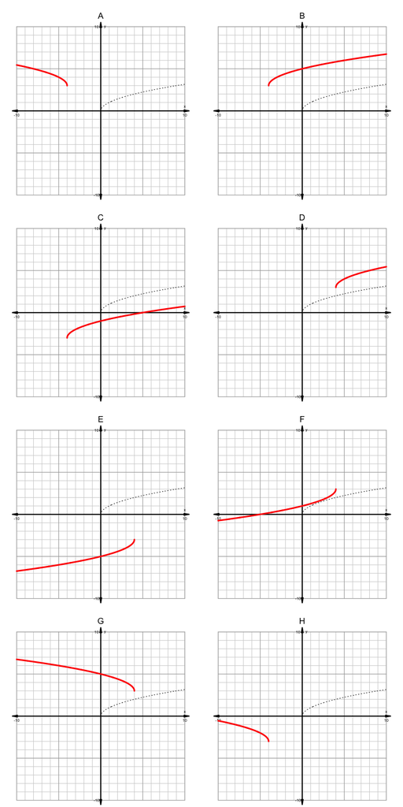

   Match the 8 graphs with the equations.
   1. Equation $y=\sqrt{-(x+4)}-3$ matches graph .
   2. Equation $y=\sqrt{-(x+4)}+3$ matches graph .
   3. Equation $y=\sqrt{-(x-4)}+3$ matches graph .
   4. Equation $y=\sqrt{x-4}+3$ matches graph .
   5. Equation $y=\sqrt{x+4}-3$ matches graph .
   6. Equation $y=-\sqrt{-(x-4)}+3$ matches graph .
   7. Equation $y=-\sqrt{-(x-4)}-3$ matches graph .
   8. Equation $y=\sqrt{x+4}+3$ matches graph .

#### Question

3. Consider the $y=\sqrt{x}$ curve shown below. In the context of transforming functions, a very simple function is often called a “parent” function.

   The following 8 graphs are made by translating and reflecting the $y=\sqrt{x}$ curve. So each one is a different daughter function, made by altering the parent function.

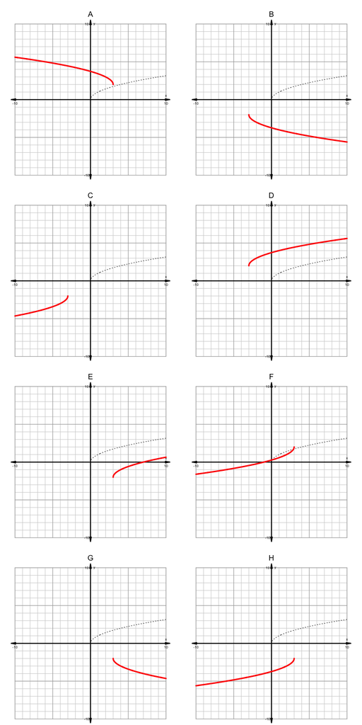

   Match the 8 graphs with the equations.
   1. Equation $y=-\sqrt{x+3}-2$ matches graph .
   2. Equation $y=-\sqrt{x-3}-2$ matches graph .
   3. Equation $y=-\sqrt{-(x-3)}-2$ matches graph .
   4. Equation $y=\sqrt{x-3}-2$ matches graph .
   5. Equation $y=\sqrt{x+3}+2$ matches graph .
   6. Equation $y=-\sqrt{-(x-3)}+2$ matches graph .
   7. Equation $y=-\sqrt{-(x+3)}-2$ matches graph .
   8. Equation $y=\sqrt{-(x-3)}+2$ matches graph .

#### Question

4. Consider the $y=\sqrt{x}$ curve shown below. In the context of transforming functions, a very simple function is often called a “parent” function.

   The following 8 graphs are made by translating and reflecting the $y=\sqrt{x}$ curve. So each one is a different daughter function, made by altering the parent function.

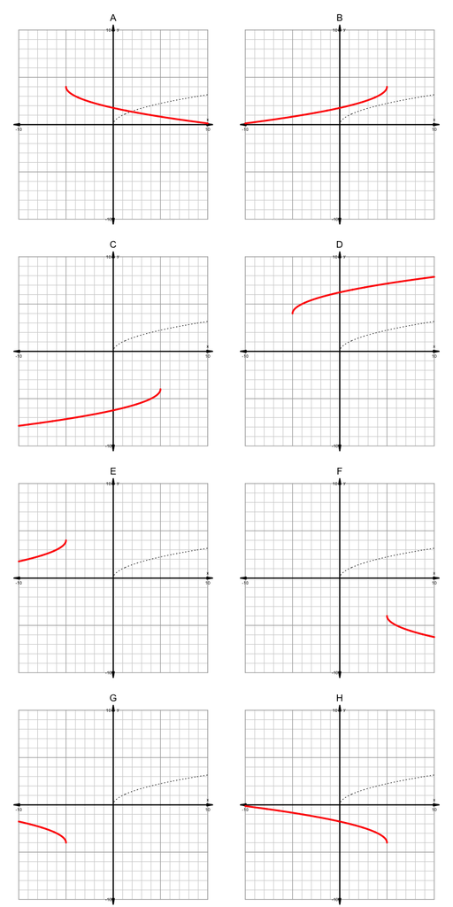

   Match the 8 graphs with the equations.
   1. Equation $y=\sqrt{-(x+5)}-4$ matches graph .
   2. Equation $y=-\sqrt{-(x-5)}-4$ matches graph .
   3. Equation $y=\sqrt{x+5}+4$ matches graph .
   4. Equation $y=-\sqrt{x+5}+4$ matches graph .
   5. Equation $y=-\sqrt{x-5}-4$ matches graph .
   6. Equation $y=\sqrt{-(x-5)}-4$ matches graph .
   7. Equation $y=-\sqrt{-(x+5)}+4$ matches graph .
   8. Equation $y=-\sqrt{-(x-5)}+4$ matches graph .

#### Question

5. Consider the $y=\sqrt{x}$ curve shown below. In the context of transforming functions, a very simple function is often called a “parent” function.

   The following 8 graphs are made by translating and reflecting the $y=\sqrt{x}$ curve. So each one is a different daughter function, made by altering the parent function.

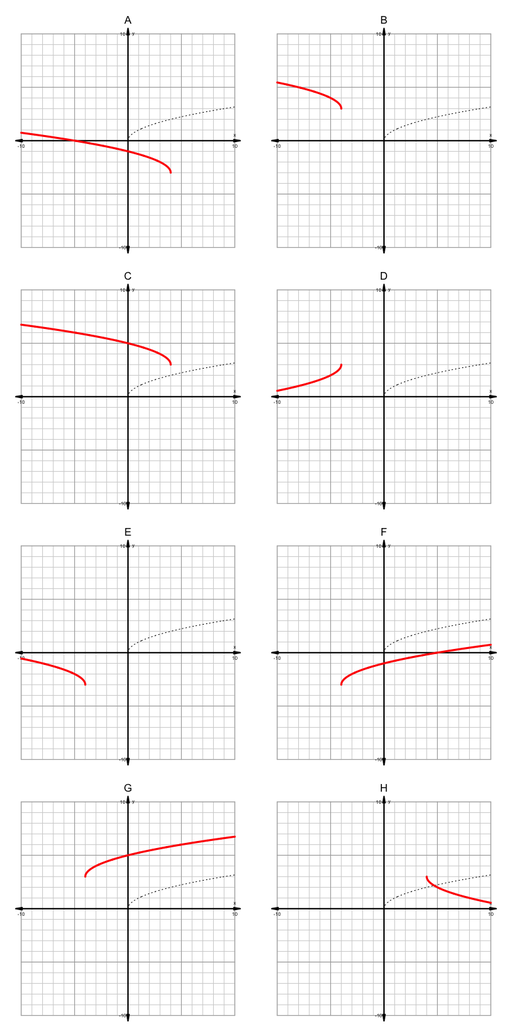

   Match the 8 graphs with the equations.
   1. Equation $y=\sqrt{-(x+4)}-3$ matches graph .
   2. Equation $y=\sqrt{-(x-4)}-3$ matches graph .
   3. Equation $y=-\sqrt{x-4}+3$ matches graph .
   4. Equation $y=\sqrt{x+4}-3$ matches graph .
   5. Equation $y=\sqrt{x+4}+3$ matches graph .
   6. Equation $y=\sqrt{-(x+4)}+3$ matches graph .
   7. Equation $y=\sqrt{-(x-4)}+3$ matches graph .
   8. Equation $y=-\sqrt{-(x+4)}+3$ matches graph .

#### Question

6. Consider the $y=\sqrt{x}$ curve shown below. In the context of transforming functions, a very simple function is often called a “parent” function.

   The following 8 graphs are made by translating and reflecting the $y=\sqrt{x}$ curve. So each one is a different daughter function, made by altering the parent function.

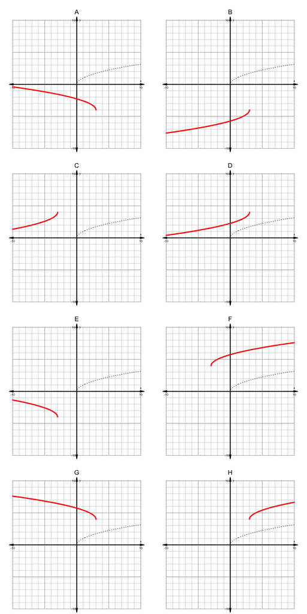

   Match the 8 graphs with the equations.
   1. Equation $y=-\sqrt{-(x-3)}+4$ matches graph .
   2. Equation $y=-\sqrt{-(x-3)}-4$ matches graph .
   3. Equation $y=\sqrt{-(x+3)}-4$ matches graph .
   4. Equation $y=\sqrt{x+3}+4$ matches graph .
   5. Equation $y=\sqrt{x-3}+4$ matches graph .
   6. Equation $y=-\sqrt{-(x+3)}+4$ matches graph .
   7. Equation $y=\sqrt{-(x-3)}+4$ matches graph .
   8. Equation $y=\sqrt{-(x-3)}-4$ matches graph .

#### Question

7. Consider the $y=\sqrt{x}$ curve shown below. In the context of transforming functions, a very simple function is often called a “parent” function.

   The following 8 graphs are made by translating and reflecting the $y=\sqrt{x}$ curve. So each one is a different daughter function, made by altering the parent function.

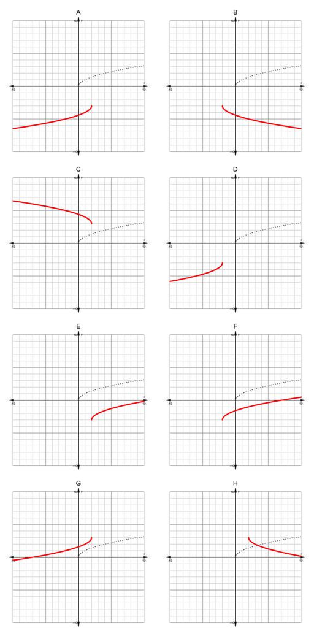

   Match the 8 graphs with the equations.
   1. Equation $y=\sqrt{x-2}-3$ matches graph .
   2. Equation $y=-\sqrt{-(x+2)}-3$ matches graph .
   3. Equation $y=-\sqrt{x+2}-3$ matches graph .
   4. Equation $y=\sqrt{x+2}-3$ matches graph .
   5. Equation $y=-\sqrt{x-2}+3$ matches graph .
   6. Equation $y=-\sqrt{-(x-2)}-3$ matches graph .
   7. Equation $y=\sqrt{-(x-2)}+3$ matches graph .
   8. Equation $y=-\sqrt{-(x-2)}+3$ matches graph .

#### Question

8. Consider the $y=\sqrt{x}$ curve shown below. In the context of transforming functions, a very simple function is often called a “parent” function.

   The following 8 graphs are made by translating and reflecting the $y=\sqrt{x}$ curve. So each one is a different daughter function, made by altering the parent function.

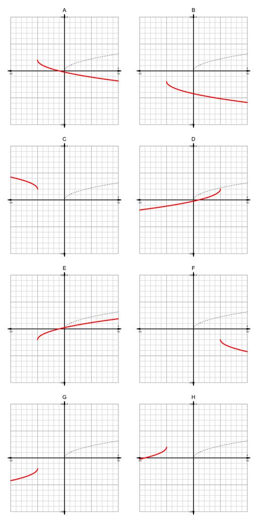

   Match the 8 graphs with the equations.
   1. Equation $y=\sqrt{-(x+5)}+2$ matches graph .
   2. Equation $y=-\sqrt{x+5}-2$ matches graph .
   3. Equation $y=-\sqrt{-(x-5)}+2$ matches graph .
   4. Equation $y=-\sqrt{x+5}+2$ matches graph .
   5. Equation $y=-\sqrt{-(x+5)}+2$ matches graph .
   6. Equation $y=\sqrt{x+5}-2$ matches graph .
   7. Equation $y=-\sqrt{x-5}-2$ matches graph .
   8. Equation $y=-\sqrt{-(x+5)}-2$ matches graph .